# Exploring Anxiety Related to AI and Job Loss Using Social Network Mining

Text Mining & Social Media Mining Project

2026-01-31

Shagufta Shaheen (477654)  
Kacper Geisshirt ( 443171)  
Szymon Grabowski (473037)

## **1.Introduction**

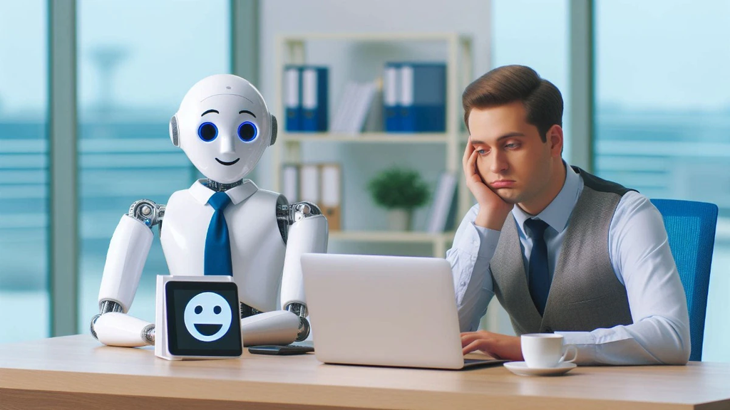

**Source:** Indiatoday,Image generated using AI

The rapid growth of Artificial Intelligence (AI) is changing the way people work. While AI brings new opportunities and improvements in efficiency, it has also created growing concerns about job security, automation, and the risk of losing employment. Many people express these worries online, sharing their thoughts, fears, and personal experiences about how AI may affect their careers and the future of work.

Social media platforms provide an important space where such concerns are openly discussed. Reddit, in particular, hosts many focused communities where users talk in detail about jobs, career uncertainty, and the impact of new technologies. Conversations about AI and job loss often reveal strong emotional reactions, including stress, fear, and anxiety, coming from people across different professions.

This project aims to highlight discussions where worries about AI, job insecurity, and anxiety appear together. By focusing on posts where these themes overlap, the study seeks to better understand how AI-driven changes in the labor market are emotionally experienced within online communities.

## **2. Data Collection**

The data for this project was collected from Reddit using the official Reddit API. OAuth-based authentication was used to obtain an access token, which allowed authorized requests to Reddit’s endpoints. Posts were collected from the following subreddits:

- `r/jobs`
- `r/cscareerquestions`
- `r/Futurology`
- `r/antiwork`
- `r/singularity`
- `r/technology`
- `r/ArtistHate`
- `r/DataScience`

For each subreddit, recent posts were retrieved using the *“new”* listing to capture the latest discussions.

All collected posts were combined into a single dataset, and duplicate posts were removed using unique post identifiers. To reduce noise and keep the dataset aligned with the project focus, only posts relevant to AI, job loss, and employment anxiety were retained. This filtering was performed using a predefined set of keywords related to artificial intelligence, automation, layoffs, unemployment, and career anxiety, such as *AI, ChatGPT, automation, layoff, unemployment, future of work,* and *UBI*.

In total, approximately **7.8 thousand raw posts** were collected from **8 different subreddits**. After merging the data and applying the keyword-based filtering, the final dataset contains **4,837 posts**, which were saved for further analysis.

## **3.Text Preprocessing and Feature Extraction**

After loading the data, basic text cleaning was applied by combining the post title and text, converting all text to lowercase, removing URLs, removing non-alphabetic characters, and trimming extra spaces. The cleaned text was stored in a new column and used as the base input for further analysis.

```r
# Initial global clean (Noise removal)
df_base_clean <- df_raw %>%
  mutate(
    text_clean = tolower(paste(title, text)),
    text_clean = str_replace_all(text_clean, "http\\S+\\s*", ""), # Remove URLs
    text_clean = str_replace_all(text_clean, "[^a-z\\s]", " "),   # Remove non-letters
    text_clean = str_squish(text_clean)                           # Remove extra spaces
  )
```

Two parallel tokenization approaches were then used. First, unigram analysis was performed by splitting the text into single words, removing stop-words and Reddit-specific noise, and applying lemmatization to normalize different word forms. Second, n-gram analysis was carried out by creating bigrams and trigrams to capture word sequences and context. Stop-words were removed from all positions in the n-grams, and additional noise terms were filtered to retain only meaningful phrases.

### a) Unigram Analysis

```r
# Define custom Reddit noise once
reddit_noise <- c("amp", "gt", "lt", "transition", "thread", "post", "edit", "don")

df_unigrams_refined <- df_base_clean %>%
  unnest_tokens(word, text_clean) %>%
  anti_join(stop_words, by = "word") %>%
  # Remove Reddit-specific noise at token level
  filter(!word %in% c("gt", "amp", "removed", "deleted")) %>%
  # Lemmatize
  mutate(lemma = lemmatize_words(word)) %>%
  # Fix known lemmatization issue
  mutate(lemma = ifelse(lemma == "datum", "data", lemma)) %>%
  # Remove additional Reddit noise at lemma level
  filter(!lemma %in% reddit_noise)

# Check top words
head(df_unigrams_refined %>% count(lemma, sort = TRUE), 10)
```

```
##      lemma    n
## 1       ai 4515
## 2      job 3931
## 3     time 2379
## 4    model 1878
## 5   people 1878
## 6     data 1855
## 7     have 1847
## 8  company 1816
## 9     feel 1588
## 10     day 1388
```

### b) N-grams Analysis

**Bigrams**

```r
# Define your custom noise list
reddit_noise <- c("amp", "gt", "lt", "transition", "thread", "post", "edit", "don")

df_bigrams_final <- df_base_clean %>%
  # 1. Create n-grams
  unnest_tokens(bigram, text_clean, token = "ngrams", n = 2) %>%

  # 2. Separate into columns for filtering/cleaning
  separate(bigram, c("word1", "word2"), sep = " ") %>%

  # 3. Filter out standard stop words AND custom reddit noise
  filter(!word1 %in% stop_words$word,
         !word2 %in% stop_words$word,
         !word1 %in% reddit_noise,
         !word2 %in% reddit_noise) %>%

  # 4. Normalize words (Lemmatize and fix the "datum" issue)
  mutate(word1 = lemmatize_words(word1),
         word2 = lemmatize_words(word2),
         word1 = ifelse(word1 == "datum", "data", word1),
         word2 = ifelse(word2 == "datum", "data", word2)) %>%

  # 5. Recombine into the final bigram string
  unite(bigram, word1, word2, sep = " ")

# Check results
head(df_bigrams_final %>% count(bigram, sort = TRUE), 20)
```

```
##               bigram   n
## 1       data science 374
## 2     data scientist 222
## 3  software engineer 167
## 4         job market 139
## 5        ai generate 127
## 6        entry level 123
## 7         job search 120
## 8      social medium 104
## 9        geminus pro  95
## 10       current job  90
## 11     data engineer  86
## 12         month ago  85
## 13     generative ai  82
## 14      hire manager  78
## 15        real world  78
## 16           ai tool  77
## 17          ai model  75
## 18          ai agent  74
## 19            ai art  69
## 20     machine learn  69
```

## **4.Text Analysis Methods**

Here, we are going to use multiple text analysis methods to study the data, combining a rule-based scoring approach with topic modeling to explore new patterns in the data.

### **4.1 Rule-based Text Classification**

The main analysis applies a keyword dictionary approach based on three thematic pillars: AI and emerging technologies, job loss and employment-related stress, and anxiety or negative sentiment. For each post, keyword-based regular expressions are used to count the presence of terms from each pillar, resulting in three scores per post: ai_score, layoff_score, and anxiety_score.

**We will calculate how many words from each list appear in every post.**

```r
# 1. Regex Patterns (Keep these the same)
ai_pattern      <- paste0("\\b(", paste(ai_terms, collapse="|"), ")\\b")
layoff_pattern  <- paste0("\\b(", paste(layoff_terms, collapse="|"), ")\\b")
anxiety_pattern <- paste0("\\b(", paste(anxiety_terms, collapse="|"), ")\\b")

# 2. Updated Scoring Engine
df_scored <- df_base_clean %>%
  mutate(
    ai_score      = str_count(text_clean, ai_pattern),
    layoff_score  = str_count(text_clean, layoff_pattern),
    anxiety_score = str_count(text_clean, anxiety_pattern),

    # NEW: Count how many DISTINCT categories have at least one hit
    # This turns (1, 5, 0) into 2 categories touched.
    categories_touched = (ai_score > 0) + (layoff_score > 0) + (anxiety_score > 0),

    # Keep your original collision score for reference
    collision_score = ai_score * layoff_score * anxiety_score
  )

# 3. Filter for 'At least 2 pillars'
# This will give you a much larger dataset for your LDA Topic Model
df_expanded_subset <- df_scored %>%
  filter(categories_touched >= 2)

# Check your new total count
print(paste("New subset size for LDA:", nrow(df_expanded_subset)))
```

```
## [1] "New subset size for LDA: 701"
```

```r
# View the top results to ensure they look relevant
df_expanded_subset %>%
  arrange(desc(categories_touched), desc(collision_score)) %>%
  select(subreddit, ai_score, layoff_score, anxiety_score, categories_touched) %>%
  head(10)
```

```
##            subreddit ai_score layoff_score anxiety_score categories_touched
## 1        DataScience        7           16             4                  3
## 2  cscareerquestions       15           16             1                  3
## 3         ArtistHate       35            1             3                  3
## 4         ArtistHate       13            2             3                  3
## 5  cscareerquestions       31            2             1                  3
## 6  cscareerquestions        6            5             2                  3
## 7        singularity        8            1             7                  3
## 8        DataScience       17            3             1                  3
## 9  cscareerquestions        6            2             3                  3
## 10        Futurology       12            3             1                  3
```

```r
df_scored %>%
  filter(collision_score > 0) %>%
  arrange(desc(collision_score)) %>%
  select(subreddit, ai_score, layoff_score, anxiety_score, collision_score) %>%
  head(10)
```

```
##            subreddit ai_score layoff_score anxiety_score collision_score
## 1        DataScience        7           16             4             448
## 2  cscareerquestions       15           16             1             240
## 3         ArtistHate       35            1             3             105
## 4         ArtistHate       13            2             3              78
## 5  cscareerquestions       31            2             1              62
## 6  cscareerquestions        6            5             2              60
## 7        singularity        8            1             7              56
## 8        DataScience       17            3             1              51
## 9  cscareerquestions        6            2             3              36
## 10        Futurology       12            3             1              36
```

```r
df_scored %>%
  summarise(
    Only_AI = sum(ai_score > 0 & layoff_score == 0 & anxiety_score == 0),
    AI_and_Layoff = sum(ai_score > 0 & layoff_score > 0),
    AI_and_Anxiety = sum(ai_score > 0 & anxiety_score > 0),
    Full_Collision = sum(collision_score > 0)
  )
```

```
##   Only_AI AI_and_Layoff AI_and_Anxiety Full_Collision
## 1    2114           406            199             85
```

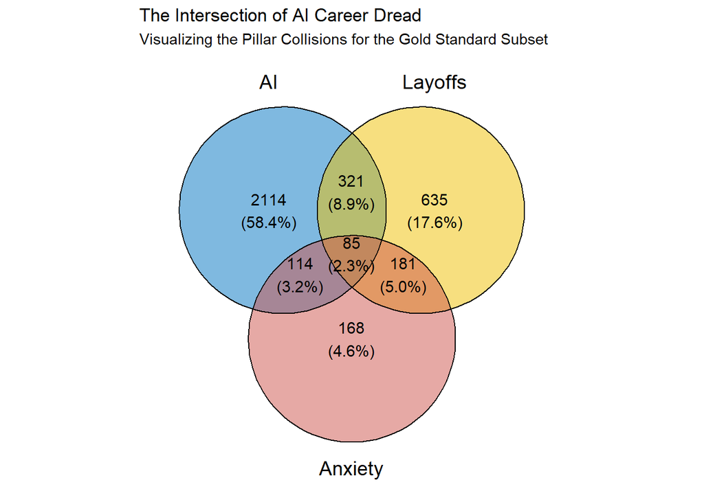

```r
library(ggvenn)

# 2. Prepare the logical list for the diagram
# We use the full df_scored to show the 'Outer' posts as well
venn_data <- list(
  AI      = which(df_scored$ai_score > 0),
  Layoffs = which(df_scored$layoff_score > 0),
  Anxiety = which(df_scored$anxiety_score > 0)
)

# 3. Create the plot
ggvenn(venn_data,
       fill_color = c("#0073C2FF", "#EFC000FF", "#CD534CFF"),
       stroke_size = 0.5,
       set_name_size = 5,
       text_size = 4) +
  labs(title = "The Intersection of AI Career Dread",
       subtitle = paste("Visualizing the Pillar Collisions for the Gold Standard Subset"))
```

```r
# See which words are the "Workhorses" (the ones doing the most filtering)
df_unigrams_refined %>%
  filter(id %in% df_expanded_subset$id) %>%
  mutate(category = case_when(
    lemma %in% ai_terms ~ "AI",
    lemma %in% layoff_terms ~ "Layoff",
    lemma %in% anxiety_terms ~ "Anxiety",
    TRUE ~ "Other"
  )) %>%
  filter(category != "Other") %>%
  count(category, lemma, sort = TRUE) %>%
  group_by(category) %>%
  slice_max(n, n = 10)
```

```
## # A tibble: 31 × 3
## # Groups:   category [3]
##    category lemma            n
##    <chr>    <chr>        <int>
##  1 AI       ai            1185
##  2 AI       model          677
##  3 AI       ml             186
##  4 AI       llm             73
##  5 AI       automation      70
##  6 AI       intelligence    64
##  7 AI       chatgpt         55
##  8 AI       gpt             51
##  9 AI       claude          48
## 10 AI       openai          41
## # ℹ 21 more rows
```

### **4.2 Topic Modeling (LDA)**

To further explore the underlying structure of discussions related to AI-driven job insecurity, Latent Dirichlet Allocation (LDA) topic modeling was applied. LDA is an unsupervised text mining technique that automatically discovers latent themes in a collection of documents based on patterns of word co-occurrence. Unlike the rule-based approach, LDA does not rely on predefined keywords and instead allows themes to emerge directly from the data. The model was applied to the subset of 701 posts identified as relevant through rule-based scoring (posts mentioning at least two thematic pillars). First, a document–term matrix was constructed using lemmatized unigrams, where each document represents a Reddit post and each term represents a normalized word. This matrix serves as the input to the LDA model.

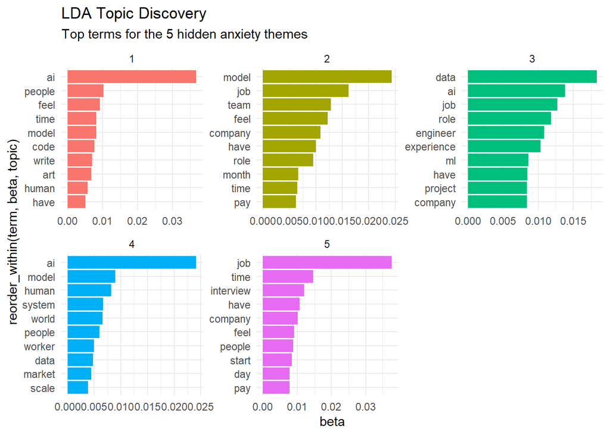

```r
# 1. Create Document-Term Matrix
# We use only the IDs from your 701-post subset
dtm_anxious <- df_unigrams_refined %>%
  filter(id %in% df_expanded_subset$id) %>%
  count(id, lemma) %>%
  cast_dtm(id, lemma, n)

# 2. Run LDA (k=5 topics)
# seed is crucial for reproducibility
lda_results <- LDA(dtm_anxious, k = 5, control = list(seed = 1234))



# 3. Get the Top 10 words per topic to see what they are
top_terms <- tidy(lda_results, matrix = "beta") %>%
  group_by(topic) %>%
  slice_max(beta, n = 10) %>%
  ungroup() %>%
  arrange(topic, -beta)

# 4. Plot the results
ggplot(top_terms, aes(beta, reorder_within(term, beta, topic), fill = factor(topic))) +
  geom_col(show.legend = FALSE) +
  facet_wrap(~ topic, scales = "free") +
  scale_y_reordered() +
  labs(title = "LDA Topic Discovery", subtitle = "Top terms for the 5 hidden anxiety themes") +
  theme_minimal()
```

An LDA model with five topics (k = 5) was then estimated, with a fixed random seed to ensure reproducibility. Each topic is represented by a probability distribution over words, and each document is represented as a mixture of topics. To interpret the topics, the top terms with the highest probabilities (beta values) were extracted for each topic and visualized.

The resulting topics reveal distinct narratives within the discussions, such as concerns about AI models and automation, job roles and career progression, data and engineering skills, broader societal impacts of AI, and interview or hiring-related stress. Together, these topics provide a deeper and more exploratory view of how anxiety related to AI and job loss is discussed, complementing the earlier rule-based classification by uncovering patterns that may not be captured by predefined keyword lists.

### **4.3 Topic Assignment to Posts**

After fitting the LDA model, each post was assigned a dominant topic based on the highest topic probability. LDA represents each post as a mixture of topics, where the gamma value indicates the proportion of a topic within a post. For each post, the topic with the highest gamma value was selected as the primary topic.

This dominant topic label was then merged back into the filtered dataset, allowing posts to be analyzed at the document level. Finally, the distribution of dominant topics across subreddits was examined to understand how different communities contribute to distinct discussion themes.

```r
post_topics <- tidy(lda_results, matrix = "gamma") %>%
  group_by(document) %>%
  slice_max(gamma, n = 1, with_ties = FALSE) %>%
  ungroup() %>%
  transmute(
    id = document,
    dominant_topic = topic,
    dominant_gamma = gamma
  )

df_final <- df_expanded_subset %>%
  inner_join(post_topics, by = "id")

# How confident are assignments?
summary(df_final$dominant_gamma)
```

```
##    Min. 1st Qu.  Median    Mean 3rd Qu.    Max.
##  0.3645  0.6469  0.8423  0.8049  0.9957  0.9998
```

```r
df_final_conf <- df_final %>% filter(dominant_gamma >= 0.40)
table(df_final_conf$subreddit, df_final_conf$dominant_topic)
```

```
##
##                       1   2   3   4   5
##   antiwork            2  10   1  12  29
##   ArtistHate         26   2   1   5   3
##   cscareerquestions  25  51 121   7  25
##   DataScience         9  17  75   9   3
##   Futurology         20   8   1  51   4
##   jobs                2  21   9   3  78
##   singularity        12   3   3  32   2
##   technology          1   0   0   7   2
```

## **5.Results and Discussion**

### **5.1 Interpretation of LDA Topics**

The LDA model identifies five distinct themes within discussions related to AI and job insecurity.

**Topic 1** reflects human-centered and creative concerns about AI, with strong emotional language and a clear concentration from the ArtistHate subreddit.

**Topic 2** captures workplace-level discussions about job roles, teams, pay, and short-term employment uncertainty, mainly from cscareerquestions, jobs, and DataScience.

**Topic 3** focuses on technical careers in AI, data science, and machine learning, highlighting concerns around skills, experience, and competition in technical job markets. This topic is dominated by cscareerquestions and DataScience.

**Topic 4** represents broader, system-level discussions about the impact of AI on workers, markets, and society, with strong contributions from Futurology and singularity.

**Topic 5** captures immediate job-search anxiety related to interviews, hiring timelines, and pay, primarily driven by posts from jobs and antiwork.

### **5.2 Temporal Trends of LDA Topics**

To examine how discussions evolve over time, posts were grouped by month and dominant LDA topic. The monthly distribution of posts for each topic was then visualized to identify temporal patterns and shifts in topic prominence.

[output not shown]

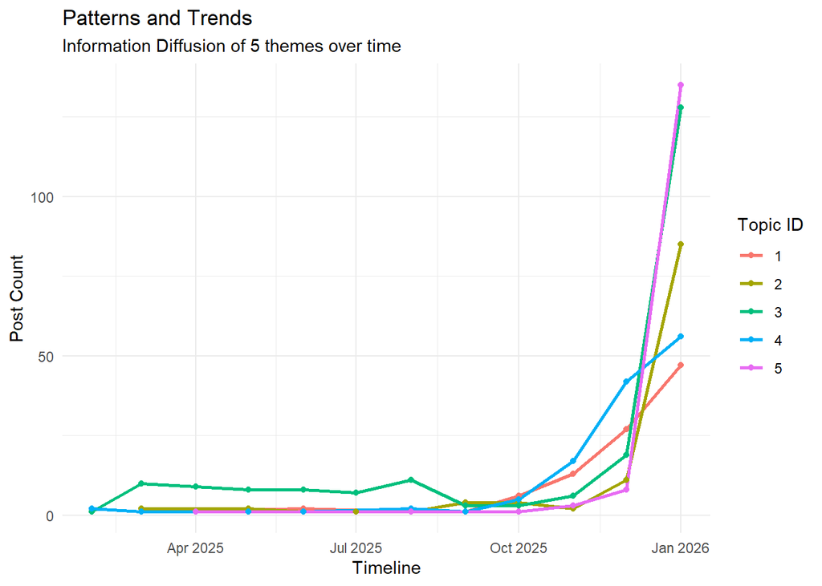

```r
df_final_results$date_clean <- as.Date(as.POSIXct(df_final_results$created_utc, origin="1970-01-01"))

# 3. Create the Time-Series Trend


df_final_results %>%
  mutate(month = floor_date(date_clean, "month")) %>%
  count(month, dominant_topic) %>%
  filter(!is.na(month)) %>%  # Remove any rows where date conversion failed
  ggplot(aes(x = month, y = n, color = factor(dominant_topic))) +
  geom_line(size = 1) +
  geom_point() +
  labs(title = "Patterns and Trends",
       subtitle = "Information Diffusion of 5 themes over time",
       x = "Timeline", y = "Post Count", color = "Topic ID") +
  theme_minimal()
```

### **5.3 Knowledge Representation**

#### **5.3.1 Subreddit–Topic Network Analysis**

This network shows which subreddits are most strongly connected to each LDA topic, based on how many posts from each subreddit were assigned to that topic.

[figure not shown]

```r
df_final_results <- df_final_results %>%
  mutate(sentiment = case_when(
    collision_score > 0.7 ~ "High Anxiety",
    collision_score > 0.4 ~ "Moderate Anxiety",
    TRUE ~ "Low Anxiety"
  ))
  library(networkD3)

# Prepare Link 1: Subreddit to Topic
links_sub_topic <- df_final_results %>%
  count(subreddit, dominant_topic) %>%
  rename(source = subreddit, target = dominant_topic, value = n) %>%
  mutate(target = paste0("Topic ", target))

# Prepare Link 2: Topic to Sentiment (Now the column exists!)
links_topic_sent <- df_final_results %>%
  count(dominant_topic, sentiment) %>%
  rename(source = dominant_topic, target = sentiment, value = n) %>%
  mutate(source = paste0("Topic ", source))

# Combine links and create Nodes
links <- rbind(links_sub_topic, links_topic_sent)
nodes <- data.frame(name = unique(c(links$source, links$target)))
links$IDsource <- match(links$source, nodes$name) - 1
links$IDtarget <- match(links$target, nodes$name) - 1

# Plot the Sankey
sankeyNetwork(Links = links, Nodes = nodes, Source = "IDsource", Target = "IDtarget",
              Value = "value", NodeID = "name", sinksRight = FALSE)
```

[interactive chart not shown]

#### **5.3.2 Word Correlation Network**

The next step builds a concept network based on word co-occurrence within posts. First, word–word correlations were computed using unigrams from the selected subset of posts. However, using all unigrams produced a very dense and visually cluttered network, dominated by frequent and general words. To improve interpretability, the analysis was refined by restricting the network to a predefined research lexicon representing the AI, job/economic, and anxiety pillars. This refinement results in a clearer and more focused network that highlights meaningful links between the three thematic pillars.

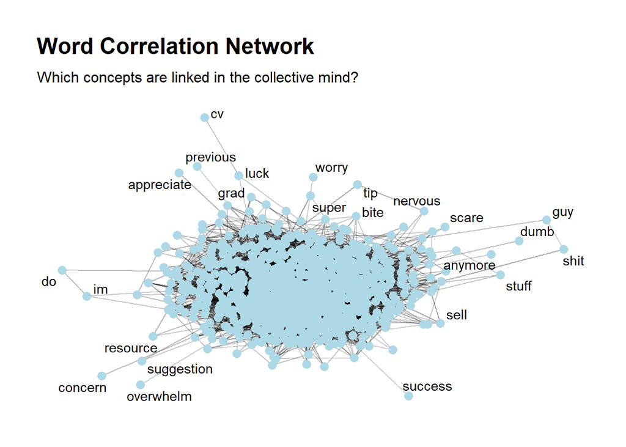

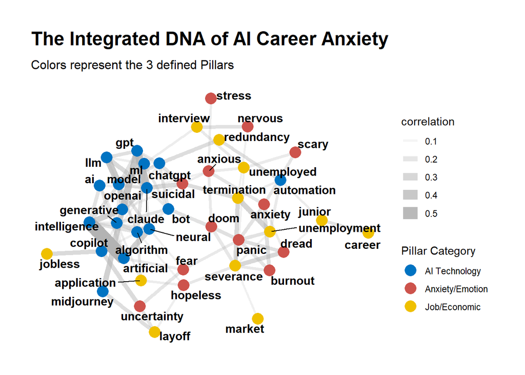

**Interactive DNA of Technology and Anxiety**

An interactive version of the network was also created using visNetwork. This allows users to explore relationships by dragging nodes and visually inspecting how concepts from AI, job insecurity, and anxiety are connected.

[interactive chart not shown]

## **6.Summary and Conclusion**

In this project, several text mining techniques were used to study online discussions related to AI, job security, and anxiety. By examining how people talk about these topics across different Reddit communities, the analysis aimed to better understand what drives work-related anxiety in the current context.

Based on the results, it appears that anxiety related to work is **not directly linked to AI or automation alone**. Instead, anxiety is more strongly connected to the **current job market situation**, such as mass layoffs, hiring freezes, long job searches, and uncertainty around interviews and salaries. While AI is frequently mentioned in discussions about the future of work, emotional stress seems to be triggered more by immediate economic pressures.

At the same time, AI and automation may still play an important indirect role. They can be seen as **underlying catalysts** that contribute to market instability, which then leads to job insecurity and anxiety. In this sense, AI is part of a broader process rather than the single cause of employee anxiety.

This project can be further extended by applying deeper analysis, such as studying trends over longer time periods, using more advanced sentiment or emotion detection techniques, or examining user-level behavior across discussions. Such extensions could provide a more detailed understanding of how technological change and market conditions together shape work-related anxiety.

## **7.Appendix**

### **Code and Data Availability**

All code used in this project, along with the extracted datasets and supporting scripts, is available on GitHub at the link below. The repository includes the complete data collection pipeline, text preprocessing steps, rule-based scoring methods, topic modeling (LDA), network visualizations, and interactive analyses presented in this report. The complete project repository can be accessed at:

🔗 **GitHub Repository:**  
https://github.com/Lunar-Vibes/Exploring-Anxiety-Related-to-AI-and-Job-Loss-Using-Social-Network-Mining

The repository contains: - Scripts for Reddit data extraction using the official API  
- Extracted datasets used for analysis  
- R Markdown files used to generate the report - Source code for all preprocessing, analysis, and visualization steps

### **Relevant Resources**

The following resources were useful for understanding the methods and tools applied in this project:

- **Reddit API Documentation**  
  https://www.reddit.com/dev/api/  
  Official documentation for accessing Reddit data programmatically.
- **tidytext: Text Mining with R**  
  https://www.tidytextmining.com/  
  A comprehensive guide to text mining using tidy data principles in R.
- **topicmodels Package (LDA in R)**  
  https://cran.r-project.org/package=topicmodels  
  Documentation for Latent Dirichlet Allocation and related topic modeling methods.
- **Network Analysis and Visualization in R (ggraph & tidygraph)**  
  https://ggraph.data-imaginist.com/  
  https://tidygraph.data-imaginist.com/  
  Resources for creating and interpreting network-based visualizations.
- **visNetwork: Interactive Network Visualization**  
  https://datastorm-open.github.io/visNetwork/  
  Documentation for building interactive network graphs in R.